# Notebook

### מלאו את הקובץ ושלחו לרז

- **ניתן למלא באנגלית או עברית**
- **מומלץ להשתמש בהמשך באותו הקובץ להגשת הפרויקט (מיחקו את התא הזה)**
- **הקפידו למלא טקסט בשדות מסוג מארק-דאון וקוד בשדות מסוג קוד (אחרת ירדו לכם נקודות)**

### מלאו את כל הסעיפים. הניקוד ינתן באופן הבא:

- **שם הפרויקט (3-4 מילים) - 5 נקודות**
- **שמות מלאים של כל חברי הצוות, ללא ת.ז - 5 נקודות**
- **תיאור הפרויקט (3-4 משפטים) - 10 נקודות**
- **קישור למקור ממנו הורדתם את הנתונים - 10 נקודות**
- **קריאת הקובץ מהגיטהאב שלכם - 10 נקודות**
- **הסבר על מקור הנתונים - 10 נקודות**
- **תיאור קצר של הדאטה בעזרת הפקודות שנלמדו בקורס - 20 נקודות**
- **שלוש שאלות ראשוניות של דברים שהיה מעניין אתכם להוציא מהקובץ - 30 נקודות**

# Project Name: Life During COVID

### Project team members:

- `אביטל זביב`
- `ראיה קשי`

### Project number:

`25`

### Project description:

`הדאטה מתעד סקר אורח חיים בתקופת מגפת הקורונה, ובוחן כיצד השפיעו השינויים החברתיים והבריאותיים על תזונה, פעילות גופנית, שינה, מצב נפשי והרגלים יומיומיים. הסקר כולל מידע אישי, רפואי והתנהגותי, ומאפשר לחקור קשרים בין משתנים כמו דיכאון, תזונה, עבודה מהבית ושימוש בטכנולוגיה. הנתונים נאספו ממשתתפים שונים לצורכי ניתוח השפעות COVID-19 על איכות חיים.`

### Link to the data:

https://github.com/ayan1c2/Survey_COVID_Lifestyle/blob/main/survey.csv

### Explain the data source:

`הנתונים נאספו באמצעות סקר מקוון שנועד לבדוק כיצד מגפת הקורונה השפיעה על אורח החיים, הבריאות הנפשית וההרגלים היומיומיים של אנשים. המשתתפים השיבו בעילום שם על שאלות הקשורות לפעילות גופנית, תזונה, מצב רגשי, שעות שינה ותנאי עבודה במהלך המגפה. הסקר פורסם לציבור על ידי המשתמש ayan1c2 ב־GitHub במסגרת פרויקט אקדמי, ונראה שהתגובות אמיתיות ונמסרו בהתנדבות.`

#### Read you file from Github:

```python
import pandas as pd

url = 'https://raw.githubusercontent.com/ayan1c2/Survey_COVID_Lifestyle/refs/heads/main/survey.csv'
survey_df = pd.read_csv(url, encoding='utf-8', on_bad_lines='skip')

survey_df.head(7)
```

|  | Age | Height | Weight | Gender | City | Educational Level | Economic Status | Dependant | Is_Employed | Is_Medically_Insured | ... | Hospitalized in a year | Regular physician consultation | Negative lifestyle | Skipping Diet | Food-type | WFH due to COVID-19 | Sedentary lifestyle due to COVID-19 | Unhealthy food habit due to COVID-19 | Addiction due to COVID | Depression |
| --- | --- | --- | --- | --- | --- | --- | --- | --- | --- | --- | --- | --- | --- | --- | --- | --- | --- | --- | --- | --- | --- |
| 0 | 50 | 129.54 | 75.0 | Male | Kolkata | Bachelors | Upper Middle Class | 4 | Full-Time | Yes | ... | Yes | No | Yes | Occasionally | Vegetarian | Yes | Yes | No | No | No |
| 1 | 26 | 180.34 | 69.0 | Male | Kolkata | Masters | Upper Middle Class | 1 | Unemployed | No | ... | No | No | Yes | Never | Vegetarian | Yes | Yes | No | No | Yes |
| 2 | 26 | 170.18 | 70.0 | Male | Kolkata | Above | Lower Middle Class | 2 | Full-Time | Yes | ... | No | No | Yes | Occasionally | Non-Veg | Yes | No | No | No | No |
| 3 | 24 | 182.88 | 85.0 | Male | Kolkata | Masters | Lower Middle Class | 1 | Part-Time | No | ... | No | No | Yes | Occasionally | Non-Veg | Sometimes | Yes | Yes | No | Yes |
| 4 | 38 | 187.96 | 93.0 | Male | Kolkata | Bachelors | Lower Middle Class | 3 | Full-Time | Yes | ... | No | Yes | No | Never | Non-Veg | Sometimes | No | No | No | No |
| 5 | 81 | 177.80 | 80.0 | Male | Kolkata | Bachelors | Upper Middle Class | 1 | Retired | Yes | ... | No | Yes | Yes | Never | Non-Veg | No | No | No | No | No |
| 6 | 28 | 152.40 | 60.0 | Female | Kolkata | Masters | Upper Middle Class | 2 | Full-Time | No | ... | No | No | No | Never | Non-Veg | Yes | Yes | No | No | No |

7 rows × 42 columns

```python
survey_df.columns
```

```
Index(['Age', 'Height', 'Weight', 'Gender', 'City', 'Educational Level',
       'Economic Status', 'Dependant', 'Is_Employed', 'Is_Medically_Insured',
       'Visit_Gym', 'Duration of daily exercise', 'Duration of daily walking',
       'Smoking Habit', 'Habit of Snus', 'Habit of Paan-Masala',
       'Habit of Alcohol', 'The habit of Energy Drinks or Sweet Beverages',
       'Mobile Application for Activity Tracking',
       'Mobile Application for Diet Tracking', 'Social Participation Type',
       'Social Participation duration', 'The habit of Vegetables',
       'Habit of Fruits', 'Habit of Junk Fried Foods', 'Habit of Sweets',
       'Habit of Red Meat', 'Habit of Taking BBQ',
       'Habit of Taking discritionary foods', 'Week_Days_sleep_time_avg',
       'Weekends_sleep_time_avg', 'Existing health problems',
       'Hospitalized in a year', 'Regular physician consultation',
       'Negative lifestyle', 'Skipping Diet', 'Food-type',
       'WFH due to COVID-19', 'Sedentary lifestyle due to COVID-19',
       'Unhealthy food habit due to COVID-19', 'Addiction due to COVID',
       'Depression'],
      dtype='object')
```

```python
survey_df.isnull().sum()
```

```
Age                                              0
Height                                           0
Weight                                           0
Gender                                           0
City                                             0
Educational Level                                0
Economic Status                                  0
Dependant                                        0
Is_Employed                                      0
Is_Medically_Insured                             0
Visit_Gym                                        0
Duration of daily exercise                       0
Duration of daily walking                        0
Smoking Habit                                    0
Habit of Snus                                    0
Habit of Paan-Masala                             0
Habit of Alcohol                                 0
The habit of Energy Drinks or Sweet Beverages    0
Mobile Application for Activity Tracking         0
Mobile Application for Diet Tracking             0
Social Participation Type                        0
Social Participation duration                    0
The habit of Vegetables                          0
Habit of Fruits                                  0
Habit of Junk Fried Foods                        0
Habit of Sweets                                  0
Habit of Red Meat                                0
Habit of Taking BBQ                              0
Habit of Taking discritionary foods              0
Week_Days_sleep_time_avg                         0
Weekends_sleep_time_avg                          0
Existing health problems                         0
Hospitalized in a year                           0
Regular physician consultation                   0
Negative lifestyle                               0
Skipping Diet                                    0
Food-type                                        0
WFH due to COVID-19                              0
Sedentary lifestyle due to COVID-19              0
Unhealthy food habit due to COVID-19             0
Addiction due to COVID                           0
Depression                                       0
dtype: int64
```

```python
survey_df.describe()
```

|  | Age | Height | Weight | Dependant | Week_Days_sleep_time_avg | Weekends_sleep_time_avg |
| --- | --- | --- | --- | --- | --- | --- |
| count | 1778.000000 | 1778.000000 | 1778.000000 | 1778.000000 | 1778.000000 | 1778.000000 |
| mean | 49.219910 | 170.911881 | 69.685996 | 22.435321 | 8.483928 | 8.680259 |
| std | 21.316795 | 10.089351 | 13.321339 | 853.712953 | 1.154645 | 1.394978 |
| min | 18.000000 | 121.920000 | 38.000000 | 1.000000 | 5.000000 | 5.000000 |
| 25% | 29.000000 | 165.100000 | 59.000000 | 1.000000 | 8.000000 | 8.000000 |
| 50% | 47.000000 | 170.180000 | 67.000000 | 2.000000 | 9.000000 | 9.000000 |
| 75% | 67.000000 | 177.800000 | 80.000000 | 3.000000 | 9.000000 | 9.000000 |
| max | 89.000000 | 210.820000 | 109.000000 | 36000.000000 | 12.000000 | 16.000000 |

#### Describe the data

- How many rows?
- How many columns?
- How many numeric columns? (not including numerical identifiers - numbers that uniquely define the row)
- How many categorical columns? (not including string identifiers - values that uniquely define the row)

```python
num_row = len(survey_df)
num_columns = len(survey_df.columns)
print(f'rows: {num_row} ,columns: {num_columns}')
```

```
rows: 1778 ,columns: 42
```

```python
print("Number of numeric columns:", len(survey_df.select_dtypes(include='number').columns))
```

```
Number of numeric columns: 6
```

```python
print("Number of categorical columns:", len(survey_df.select_dtypes(include='object').columns))
```

```
Number of categorical columns: 36
```

#### Write three questions you would like to answer using this data

1. האם קיים קשר בין תדירות פעילות גופנית לבין רמת דיכאון או מצב נפשי?
2. (WFH)כיצד עבודה מהבית משפיעה על הרגלי התזונה והשינה של משתתפים?
3. כיצד הרגלים מזיקים כמו עישון ושתיית אלכוהול משתנים בהתאם לרמת המעמד הכלכלי של המשתתפים?

### Observation 1:

האם קיים קשר בין תדירות פעילות גופנית לבין רמת דיכאון או מצב נפשי?

### 🧠 הקשר בין פעילות גופנית לדיכאון

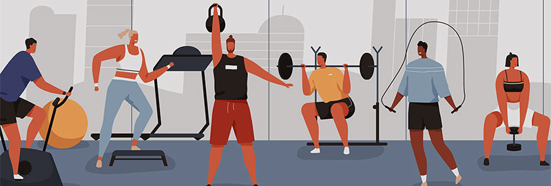

```python
import pandas as pd
import matplotlib.pyplot as plt
import seaborn as sns
```

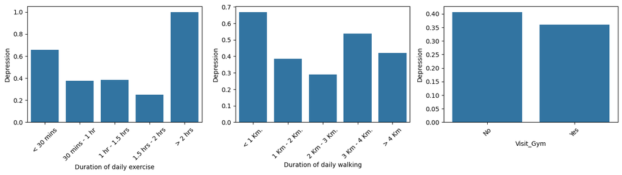

```python
df_Q1 = survey_df[['Visit_Gym', 'Duration of daily exercise', 'Duration of daily walking', 'Depression']].copy()

df_Q1['Depression'] = df_Q1['Depression'].map({'Yes': 1, 'No': 0})

order_exercise=['< 30 mins', '30 mins - 1 hr', '1 hr - 1.5 hrs', '1.5 hrs - 2 hrs','> 2 hrs']
order_walking=['< 1 Km.', '1 Km - 2 Km.', '2 Km - 3 Km.','3 Km - 4 Km.','> 4 Km']

fig, axes = plt.subplots(1, 3, figsize=(14,4))

sns.barplot(x='Duration of daily exercise', y='Depression', data=df_Q1, ax=axes[0], errorbar=None,order= order_exercise)
axes[0].tick_params(axis='x', rotation=45)

sns.barplot(x='Duration of daily walking', y='Depression', data=df_Q1, ax=axes[1], errorbar=None,order= order_walking)
axes[1].tick_params(axis='x', rotation=45)

sns.barplot(x='Visit_Gym', y='Depression', data=df_Q1, ax=axes[2], errorbar=None)
axes[2].tick_params(axis='x', rotation=45)

plt.tight_layout()
plt.show()
```

```python
df_Q1['Duration of daily exercise'].value_counts()
```

```
Duration of daily exercise
30 mins - 1 hr     1176
1 hr - 1.5 hrs      244
< 30 mins           200
1.5 hrs - 2 hrs     157
> 2 hrs               1
Name: count, dtype: int64
```

```python
df_Q1['Duration of daily walking'].value_counts()
```

```
Duration of daily walking
1 Km - 2 Km.    1430
2 Km - 3 Km.     183
< 1 Km.          133
> 4 Km            19
3 Km - 4 Km.      13
Name: count, dtype: int64
```

קטגוריות שבהן מספר המשיבים היה נמוך במיוחד הוסרו מהגרפים, מתוך מטרה לשמור על מהימנות התוצאות.  
כאשר משתתף בודד משתייך לקטגוריה מסוימת ומדווח על דיכאון – התוצאה מוצגת כ־100%, דבר שעלול להטעות וליצור רושם שגוי של קשר חזק.  
כדי למנוע עיוותים כאלה, נכללו בגרפים רק קטגוריות בעלות גודל מדגם מספק (למשל, מעל 30 משתתפים),  
באופן שמאפשר להציג מגמות מובהקות ויציבות סטטיסטית.

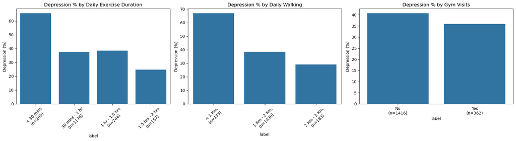

```python
df_Q1 = survey_df[['Visit_Gym', 'Duration of daily exercise', 'Duration of daily walking', 'Depression']].copy()

df_Q1['Depression'] = df_Q1['Depression'].map({'Yes': 1, 'No': 0})

order_exercise = ['< 30 mins', '30 mins - 1 hr', '1 hr - 1.5 hrs', '1.5 hrs - 2 hrs', '> 2 hr']
order_walking = ['< 1 Km.', '1 Km - 2 Km.', '2 Km - 3 Km.', '3 Km - 4 Km.', '> 4 Km.']
order_binary = ['No', 'Yes']

def calc_depression_rate(df, column, order=None, min_count=30):
    stats = df.groupby(column)['Depression'].agg(['mean', 'count']).reset_index()
    stats = stats[stats['count'] >= min_count]
    stats['Depression_Percent'] = (stats['mean'] * 100).round(1)
    if order:
        stats[column] = pd.Categorical(stats[column], categories=order, ordered=True)
        stats = stats.sort_values(column)
    stats['label'] = stats.apply(lambda row: f"{row[column]}\n(n={int(row['count'])})", axis=1)
    return stats

exercise_rates = calc_depression_rate(df_Q1, 'Duration of daily exercise', order_exercise)
walking_rates = calc_depression_rate(df_Q1, 'Duration of daily walking', order_walking)
gym_rates = calc_depression_rate(df_Q1, 'Visit_Gym', order_binary)

fig, axes = plt.subplots(1, 3, figsize=(18, 5))

sns.barplot(x='label', y='Depression_Percent', data=exercise_rates, ax=axes[0])
axes[0].set_title('Depression % by Daily Exercise Duration')
axes[0].set_ylabel('Depression (%)')
axes[0].tick_params(axis='x', rotation=45)

sns.barplot(x='label', y='Depression_Percent', data=walking_rates, ax=axes[1])
axes[1].set_title('Depression % by Daily Walking')
axes[1].set_ylabel('Depression (%)')
axes[1].tick_params(axis='x', rotation=45)

sns.barplot(x='label', y='Depression_Percent', data=gym_rates, ax=axes[2])
axes[2].set_title('Depression % by Gym Visits')
axes[2].set_ylabel('Depression (%)')

plt.tight_layout()
plt.show()
```

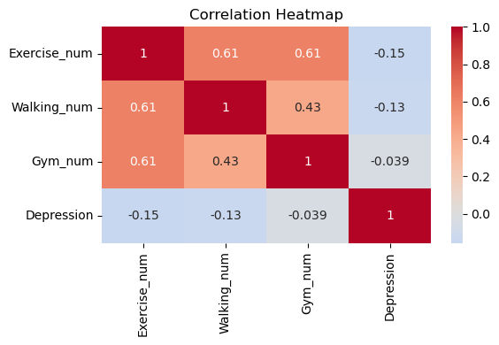

```python
exercise_map = {'< 30 mins': 0, '30 mins - 1 hr': 1, '1 hr - 1.5 hrs': 2, '1.5 hrs - 2 hrs': 3, '> 2 hr': 4}
walking_map = {'< 1 Km.': 0, '1 Km - 2 Km.': 1, '2 Km - 3 Km.': 2, '3 Km - 4 Km.': 3, '> 4 Km.': 4}
binary_map = {'No': 0, 'Yes': 1}

df_corr = df_Q1.copy()
df_corr['Exercise_num'] = df_corr['Duration of daily exercise'].map(exercise_map)
df_corr['Walking_num'] = df_corr['Duration of daily walking'].map(walking_map)
df_corr['Gym_num'] = df_corr['Visit_Gym'].map(binary_map)
corr_df = df_corr[['Exercise_num', 'Walking_num', 'Gym_num', 'Depression']].corr()

plt.figure(figsize=(6, 4))
sns.heatmap(corr_df, annot=True, cmap='coolwarm', center=0)
plt.title('Correlation Heatmap')
plt.tight_layout()
plt.show()
```

- פעילות גופנית והליכה נמצאו בקשר שלילי (חיובי) עם רמת הדיכאון,( **-0.15**)

-והליכה נמצאה בקשר שלילי (חיובי) עם רמת הדיכאון,( **-0.13**) כלומר ככל שפעילים יותר – מדווחים פחות על דיכאון.

- הקשר בין דיכאון וחדר כושר שלילי חלש מה שמראה שאין קשר מובהק( **-0.039**)
- הקשר בין המשתנים הפיזיים עצמם (אימון, הליכה, חדר כושר) חזק יותר – מה שמעיד על דפוס כללי של סגנון חיים פעיל.(זמן פעילות והליכה **0.61**), (חדר כושר והליכה **0.43**)

### Observation 2:

2. (WFH)כיצד עבודה מהבית משפיעה על הרגלי התזונה והשינה של משתתפים?

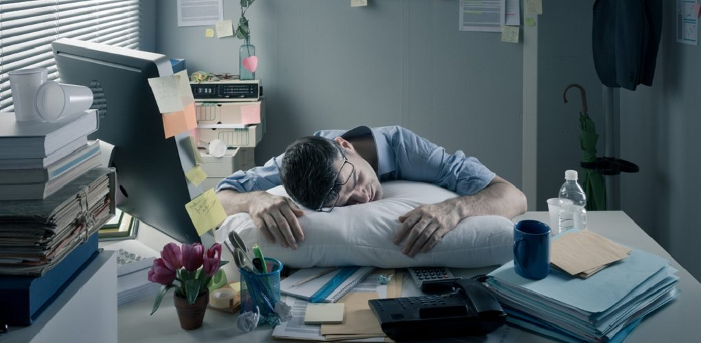

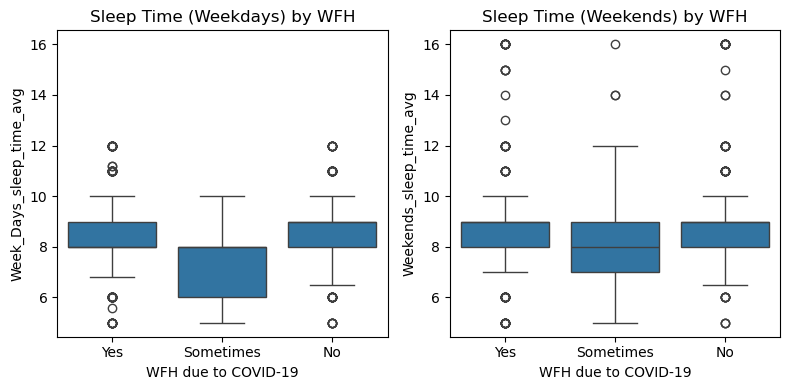

```python
sleep_df = survey_df[['WFH due to COVID-19', 'Week_Days_sleep_time_avg', 'Weekends_sleep_time_avg']]
fig, axes = plt.subplots(1,2, figsize=(8,4))

sns.boxplot(data=sleep_df, x='WFH due to COVID-19', y='Week_Days_sleep_time_avg',ax=axes[0])
axes[0].set_title('Sleep Time (Weekdays) by WFH')

sns.boxplot(data=sleep_df, x='WFH due to COVID-19', y='Weekends_sleep_time_avg',ax=axes[1])
axes[1].set_title('Sleep Time (Weekends) by WFH')

axes[0].set_ylim(axes[1].get_ylim())

plt.tight_layout()
plt.show()
```

### 💤 ממצא עיקרי לגבי השפעת עבודה מהבית על שעות שינה

קבוצת המשתתפים שציינו כי הם עובדים מהבית **לעיתים (Sometimes)** הציגה שינוי בולט בזמני השינה בין ימי חול לסופי שבוע – הם ישנים **הרבה יותר בסופי שבוע** בהשוואה לשאר הקבוצות.

ייתכן שהדבר נובע מחוסר שגרה או מאיזון משתנה בין בית לעבודה, שמוביל לצורך לפצות על שעות שינה אבודות בסופ"ש.

לעומתם, משתתפים שעובדים מהבית באופן קבוע (Yes) או כלל לא עובדים מהבית (No), מציגים דפוס שינה עקבי יותר בין ימות השבוע לסוף השבוע – דבר שעשוי להעיד על סדר יום יציב יותר.

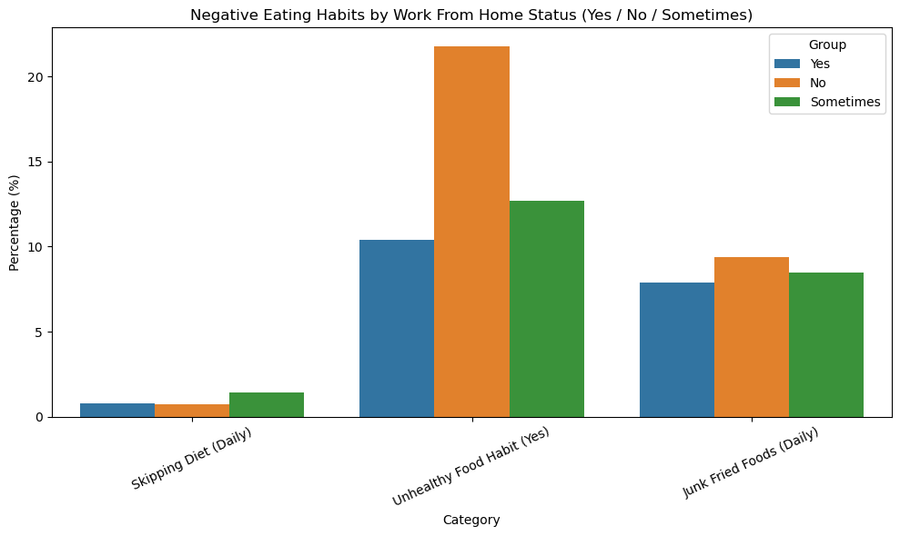

```python
def get_percent(df, column, positive_val):
    summary = (df.groupby(['WFH due to COVID-19', column]).size().unstack().fillna(0))
    percent = (summary[positive_val] / summary.sum(axis=1) * 100).round(1)
    return percent

skipping_percent = get_percent(survey_df, 'Skipping Diet', 'Daily')
unhealthy_percent = get_percent(survey_df, 'Unhealthy food habit due to COVID-19', 'Yes')
junkfood_percent = get_percent(survey_df, 'Habit of Junk Fried Foods', 'Daily')

plot_df = pd.DataFrame({
    'Category': ['Skipping Diet (Daily)', 'Unhealthy Food Habit (Yes)', 'Junk Fried Foods (Daily)'],
    'Yes': [skipping_percent.get('Yes', 0), unhealthy_percent.get('Yes', 0), junkfood_percent.get('Yes', 0)],
    'No': [skipping_percent.get('No', 0), unhealthy_percent.get('No', 0), junkfood_percent.get('No', 0)],
    'Sometimes': [skipping_percent.get('Sometimes', 0), unhealthy_percent.get('Sometimes', 0), junkfood_percent.get('Sometimes', 0)]
}).melt(id_vars='Category', var_name='Group', value_name='Percentage')

plt.figure(figsize=(10, 6))
sns.barplot(data=plot_df, x='Category', y='Percentage', hue='Group')
plt.title('Negative Eating Habits by Work From Home Status (Yes / No / Sometimes)')
plt.ylabel('Percentage (%)')
plt.xticks(rotation=25)
plt.tight_layout()
plt.show()
```

#### סיכום השוואתי:

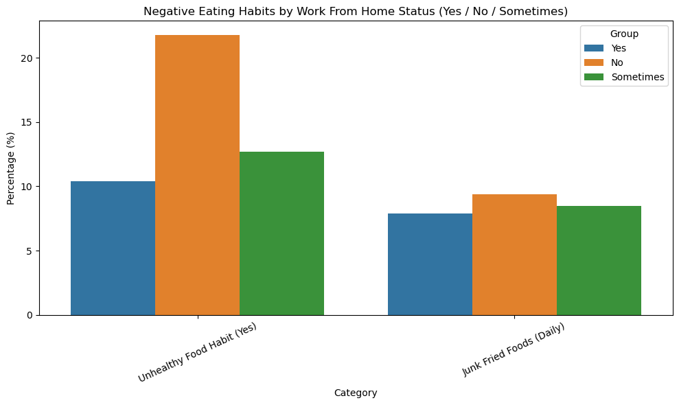

```python
def get_percent(df, column, positive_val):
    summary = (df.groupby(['WFH due to COVID-19', column]).size().unstack().fillna(0))
    percent = (summary[positive_val] / summary.sum(axis=1) * 100).round(1)
    return percent

unhealthy_percent = get_percent(survey_df, 'Unhealthy food habit due to COVID-19', 'Yes')
junkfood_percent = get_percent(survey_df, 'Habit of Junk Fried Foods', 'Daily')

plot_df = pd.DataFrame({
    'Category': ['Unhealthy Food Habit (Yes)', 'Junk Fried Foods (Daily)'],
    'Yes': [unhealthy_percent.get('Yes', 0), junkfood_percent.get('Yes', 0)],
    'No': [unhealthy_percent.get('No', 0), junkfood_percent.get('No', 0)],
    'Sometimes': [unhealthy_percent.get('Sometimes', 0), junkfood_percent.get('Sometimes', 0)]
}).melt(id_vars='Category', var_name='Group', value_name='Percentage')

plt.figure(figsize=(10, 6))
sns.barplot(data=plot_df, x='Category', y='Percentage', hue='Group')
plt.title('Negative Eating Habits by Work From Home Status (Yes / No / Sometimes)')
plt.ylabel('Percentage (%)')
plt.xticks(rotation=25)
plt.tight_layout()
plt.show()
```

### הסרת מדד "דילוג על ארוחות"

הקטגוריה של **"Skipping Diet (Daily)"** הוסרה מהגרף בשל **מספר משיבים נמוך מאוד** שדיווחו על הרגל זה – רק **14 משתתפים**.  
כתוצאה מכך, כל חישוב של אחוזים עבור קבוצה זו **עלול להטעות** ולהציג אחוזים קיצוניים שאינם משקפים מגמה אמיתית באוכלוסייה.

לדוגמה, אם מתוך 14 איש – רובם עובדים מהבית – הגרף עשוי להציג כאילו 100% מהעובדים מהבית מדלגים על ארוחות, אף שזו **קבוצה קטנה מדי** לניתוח משמעותי.  
בשל כך, הוחלט להתמקד בקטגוריות שמכילות **מספר מספק של משיבים**, כמו:

🟢 7 אנשים עובדים מהבית (Yes)

🔴 6 אנשים לא עובדים מהבית (No)

🟡 1 אדם אחד בלבד עובד מהבית לפעמים (Sometimes)

```python
survey_df['Skipping Diet'].value_counts()
```

```
Skipping Diet
Never           1227
Occasionally     537
Daily             14
Name: count, dtype: int64
```

### Observation 3:

3. כיצד הרגלים מזיקים כמו עישון ושתיית אלכוהול משתנים בהתאם לרמת המעמד הכלכלי של המשתתפים?

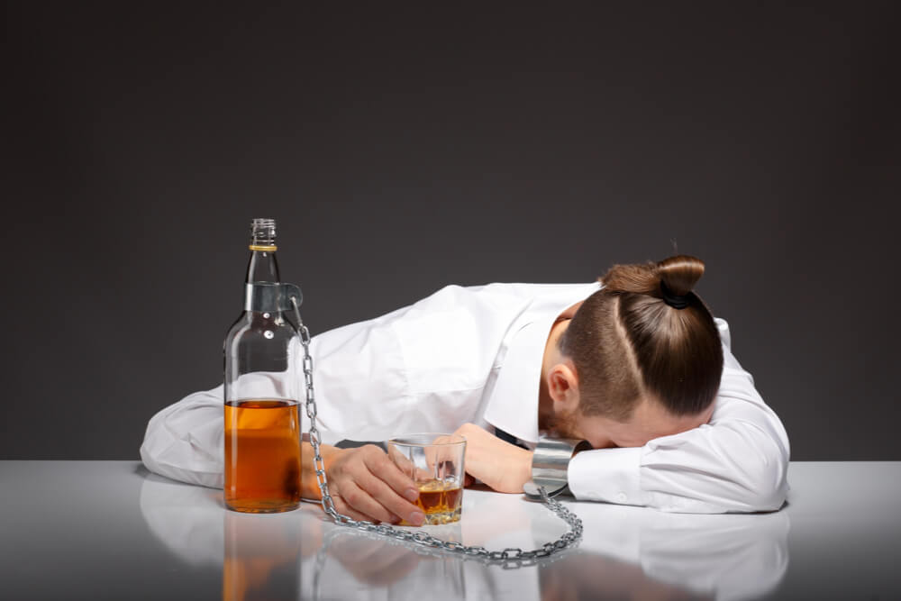

```python
survey_df['Economic Status'].value_counts()
```

```
Economic Status
Middle Class          1253
Lower Middle Class     211
Upper Middle Class     171
Rich                   120
Upper Income Class      22
Poverty Line             1
Name: count, dtype: int64
```

```python
economic_mapping = {'Poverty Line': 'Lower Class','Lower Middle Class': 'Lower Class',
                    'Middle Class': 'Middle Class',
                    'Upper Middle Class': 'Upper Class','Upper Income Class': 'Upper Class','Rich': 'Upper Class'}

survey_df['Economic_Group'] = survey_df['Economic Status'].map(economic_mapping)

group_counts = survey_df['Economic_Group'].value_counts()

print("מספר האנשים בכל קבוצה כלכלית לאחר איחוד:")
print(group_counts)
```

```
מספר האנשים בכל קבוצה כלכלית לאחר איחוד:
Economic_Group
Middle Class    1253
Upper Class      313
Lower Class      212
Name: count, dtype: int64
```

לאור הפיזור הלא אחיד של המשיבים בין הקבוצות הכלכליות השונות, החלטנו לאחד מספר קטגוריות על מנת לקבל תובנות משמעותיות יותר. בקבוצות כמו "Upper Income Class" ו־"Poverty Line" מספר המשיבים היה נמוך במיוחד, דבר שעלול להוביל להסקת מסקנות שגויות או לא מייצגות. לכן, הקטגוריות אוחדו לשלוש קבוצות עיקריות: "Lower Class", "Middle Class", ו־"Upper Class". חלוקה זו מאפשרת ניתוח יציב יותר של הנתונים תוך שמירה על המשמעות הסוציו־אקונומית של הסיווג המקורי.

```python
survey_df['Smoking Habit'].value_counts()
```

```
Smoking Habit
Never           1329
Occasionally     305
Daily            144
Name: count, dtype: int64
```

```python
survey_df['Habit of Alcohol'].value_counts()
```

```
Habit of Alcohol
Never           1079
Occasionally     623
Daily             76
Name: count, dtype: int64
```

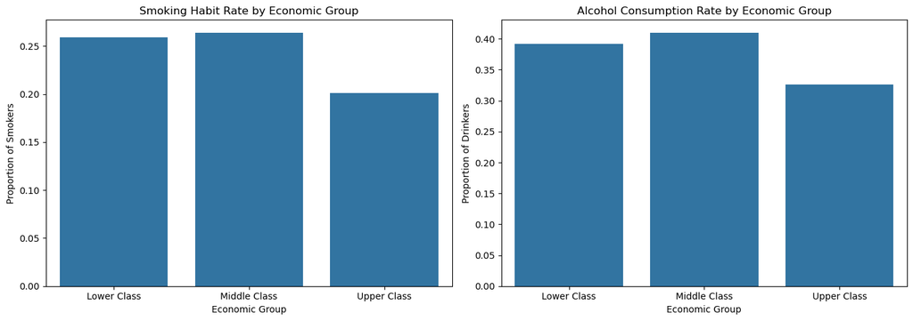

```python
survey_df['Smoker'] = survey_df['Smoking Habit'].isin(['Occasionally', 'Daily'])
survey_df['Drinker'] = survey_df['Habit of Alcohol'].isin(['Occasionally', 'Daily'])

smoking_rates = survey_df.groupby('Economic_Group')['Smoker'].mean().reindex(['Lower Class', 'Middle Class', 'Upper Class']).reset_index()
alcohol_rates = survey_df.groupby('Economic_Group')['Drinker'].mean().reindex(['Lower Class', 'Middle Class', 'Upper Class']).reset_index()

fig, axes = plt.subplots(1, 2, figsize=(14, 5))

sns.barplot(data=smoking_rates, x='Economic_Group', y='Smoker', ax=axes[0])
axes[0].set_title('Smoking Habit Rate by Economic Group')
axes[0].set_ylabel('Proportion of Smokers')
axes[0].set_xlabel('Economic Group')

sns.barplot(data=alcohol_rates, x='Economic_Group', y='Drinker', ax=axes[1])
axes[1].set_title('Alcohol Consumption Rate by Economic Group')
axes[1].set_ylabel('Proportion of Drinkers')
axes[1].set_xlabel('Economic Group')

plt.tight_layout()
plt.show()
```

### 🧾 סיכום ממצאים – הקשר בין מצב כלכלי להרגלים מזיקים

הניתוח בחן את הקשר בין רמת המצב הכלכלי של המשתתפים לבין הרגלים מזיקים, בדגש על **עישון** ו**שתיית אלכוהול**.

איחדנו את אלה שמעשנים\שותים לפעמים ובאופן יום יומי מכיוון שאנחנו רוצים להבין את שיעור החשיפה להרגל מזיק, בלי לבדוק רמות שונות של שימוש.

- 🔥 **עישון**: שיעור המעשנים היה **הגבוה ביותר בקבוצות "מעמד נמוך" ו"מעמד בינוני"**, בעוד שבקרב בעלי **מעמד כלכלי גבוה נרשמה ירידה ברורה בעישון**. זה עשוי להעיד על מודעות בריאותית גבוהה יותר או נגישות טובה יותר למשאבים תומכים.
- 🍷 **צריכת אלכוהול**: גם כאן נראתה **צריכה גבוהה יותר בקרב המעמדות הנמוך והבינוני**, כאשר **המעמד הגבוה מדווח על שיעור צריכה נמוך יחסית**.

לסיכום, בעלי מעמד כלכלי גבוה נוטים לאמץ הרגלים בריאים יותר, בעוד שבקרב בעלי מעמד כלכלי נמוך יותר ניכרת נטייה גבוהה יותר לעישון ושתייה.

### Summary

> Anything you'd like to say - your conclusions, summary, how hard you worked etc.

### 📝 סיכום

עבדנו קשה על הבנת הנתונים, ניקוי ראשוני, ביצוע ניתוחים סטטיסטיים בסיסיים והצבת שאלות מחקריות רלוונטיות למציאות החיים בתקופת הקורונה. נתקלנו באתגרים כמו חוסרים במשיבים על קטגוריה ספציפית מתוך אוכלוסיה מסומיימת בסקר (מה שגרם לנו להטעיה במסקנות הראשוניות), הבנת מבנה הדאטה, ועבודה עם משתנים רבים, אך בעבודה משותפת והתמדה הצלחנו להתגבר עליהם.

בסופו של דבר, הפרויקט אפשר לנו להבין טוב יותר את ההשפעות של הרגלים מסויימים או מצב סוציואקונומי של אוכלוסיה מסויימת על אורח חיים, ולחזק את היכולות שלנו בניתוח נתונים בעזרת פייתון וכלים מתקדמים. נהנינו מאוד מהתהליך, למדנו רבות, ואנו גאות בתוצאה.